# Plasma proteomics of pleural infection

Results from Olink Target 96 Inflammation panel

Paul Yousefi

27 October 2026

# Protein measurements

Of the **plasma** samples run, 81 passed the default qc performed in the `metaboprep` package and instituted by the lab.

For the moment, all 92 measured proteins have been retained for analysis.

See plasmametaboprep_qc_report.html for full details.

# Population description

## Sample characteristics table

|  | level | Overall |
| --- | --- | --- |
| n |  | 81 |
| age (mean (SD)) |  | 61.90 (19.05) |
| female (%) | 0 | 50 (61.7) |
|  | 1 | 31 (38.3) |
| plate (%) | GB390725-RB_4 | 81 (100.0) |
| infect.fct (%) | control | 16 (19.8) |
|  | inter | 22 (27.2) |
|  | case | 43 (53.1) |
| infect.num (%) | 1 | 16 (19.8) |
|  | 2 | 22 (27.2) |
|  | 3 | 43 (53.1) |
| infect.bi (%) | 0 | 38 (46.9) |
|  | 1 | 43 (53.1) |
| comp.out (%) | 0 | 47 (58.0) |
|  | 1 | 34 (42.0) |
| infect.bi.new (%) | 0 | 38 (46.9) |
|  | 1 | 43 (53.1) |
| final.diagnosis.1 (%) | X/infection/bacterial | 11 (13.6) |
|  | X/infection/CPPE | 22 (27.2) |
|  | X/infection/SPE | 16 (19.8) |
|  | X/infection/utrue | 32 (39.5) |

## Variable definitions

### infection

`final.diagnosis.1` was used to derive the infection status variables begining with `infect`.

`infect.fct` and `infect.num` are identical 3-level variables, except the first is formatted as factor while the second is formatted as numeric.

The levels of these variables are defined as follows:

1. Control: `final.diagnosis.1`= “SPE”
2. Inter: `final.diagnosis.1` = “CPPE”
3. Case: `final.diagnosis.1`= “utrue” or `final.diagnosis.1`= “bacterial”

`infect.bi` is just the cases from above i.e. `infect.num` >2

`infect.bi.new` is `infect.bi` with N= 0 additional controls included who had `final.diagnosis.1` values equal to “X/renal/u”, “X/hepatic/u”, or “X/cardiac/u”.

### comp out

`comp.out` is a variable I received with the title: “composite.outcome..lytics..surgery.or..3m.mortality”

# Protein-wide associations

Phenotypic characteristics of participants described in Phenotype information were examined for association with protein abundances (Protein measurements)

## Models

The formulae of linear models examined are shown in the table below:

```
> $plasma.infect.fct
> methylation ~ infect.fct
> <environment: 0x56173cf519b8>
>
> $plasma.infect.num
> methylation ~ infect.num
> <environment: 0x56173cf4e860>
>
> $plasma.infect.bi
> methylation ~ infect.bi
> <environment: 0x56173cdd5c98>
>
> $plasma.comp.out
> methylation ~ comp.out
> <environment: 0x56173cdd2ad0>
>
> $plasma.infect.bi.new
> methylation ~ infect.bi.new
> <environment: 0x56173cdcbad8>
>
> $plasma.female
> methylation ~ female
> <environment: 0x56173cdc8910>
>
> $plasma.age
> methylation ~ age
> <environment: 0x56173cdc1ad8>
>
> $plasma.infect.fct.fulladj
> methylation ~ infect.fct + female + age
> <environment: 0x56173cdbeb40>
>
> $plasma.infect.num.fulladj
> methylation ~ infect.num + female + age
> <environment: 0x56173cdbbaf8>
>
> $plasma.infect.bi.fulladj
> methylation ~ infect.bi + female + age
> <environment: 0x56173cdb4e10>
>
> $plasma.comp.out.fulladj
> methylation ~ comp.out + female + age
> <environment: 0x56173cdae208>
>
> $plasma.infect.bi.new.fulladj
> methylation ~ infect.bi.new + female + age
> <environment: 0x56173cdab4a0>
```

## Count of significant hits

Number of significant hits identified per model. Statistical significance was determined using a Bonferroni multiple testing threshold correcting for 92 tests. That is 0.05/ 92 = 5.43e-04

| model | n.bonf.sig | n.fdr.sig |
| --- | --- | --- |
| plasma.infect.fct | 4 | 6 |
| plasma.infect.num | 4 | 15 |
| plasma.infect.bi | 3 | 11 |
| plasma.comp.out | 5 | 15 |
| plasma.infect.bi.new | 3 | 11 |
| plasma.female | 0 | 0 |
| plasma.age | 6 | 14 |
| plasma.infect.fct.fulladj | 4 | 4 |
| plasma.infect.num.fulladj | 4 | 19 |
| plasma.infect.bi.fulladj | 3 | 10 |
| plasma.comp.out.fulladj | 5 | 10 |
| plasma.infect.bi.new.fulladj | 3 | 10 |

## All models

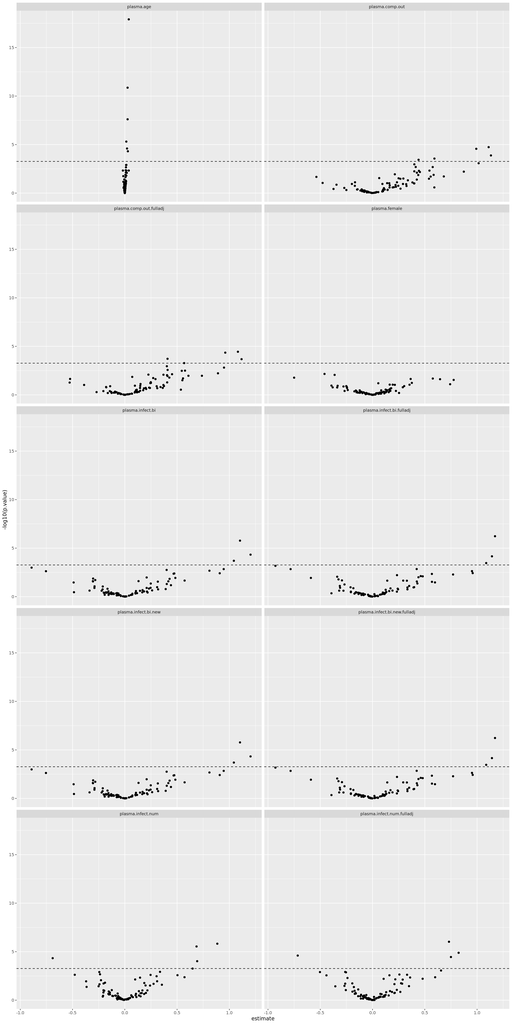

## Main models with annotated hits

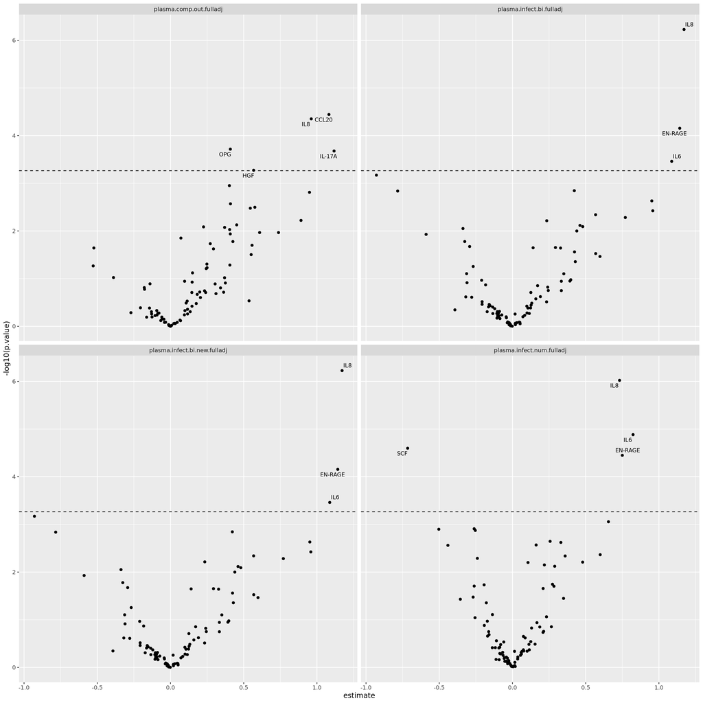

## Top hits

Results of all Bonferroni-significant hits for main models:

$plasma.infect.num.fulladj

| gene | n | estimate | se | p.value | p.adjust |
| --- | --- | --- | --- | --- | --- |
| IL8 | 81 | 0.73 | 0.14 | 9.5e-07 | 8.7e-05 |
| IL6 | 81 | 0.82 | 0.18 | 1.3e-05 | 1.2e-03 |
| SCF | 81 | -0.72 | 0.16 | 2.5e-05 | 2.3e-03 |
| EN-RAGE | 81 | 0.75 | 0.17 | 3.6e-05 | 3.3e-03 |

$plasma.infect.bi.fulladj

| gene | n | estimate | se | p.value | p.adjust |
| --- | --- | --- | --- | --- | --- |
| IL8 | 81 | 1.17 | 0.22 | 5.9e-07 | 5.5e-05 |
| EN-RAGE | 81 | 1.14 | 0.27 | 7.0e-05 | 6.4e-03 |
| IL6 | 81 | 1.09 | 0.29 | 3.5e-04 | 3.2e-02 |

$plasma.comp.out.fulladj

| gene | n | estimate | se | p.value | p.adjust |
| --- | --- | --- | --- | --- | --- |
| CCL20 | 81 | 1.08 | 0.25 | 3.6e-05 | 3.3e-03 |
| IL8 | 81 | 0.96 | 0.22 | 4.5e-05 | 4.1e-03 |
| OPG | 81 | 0.41 | 0.10 | 1.9e-04 | 1.8e-02 |
| IL-17A | 81 | 1.12 | 0.29 | 2.1e-04 | 1.9e-02 |
| HGF | 81 | 0.57 | 0.16 | 5.3e-04 | 4.9e-02 |

$plasma.infect.bi.new.fulladj

| gene | n | estimate | se | p.value | p.adjust |
| --- | --- | --- | --- | --- | --- |
| IL8 | 81 | 1.17 | 0.22 | 5.9e-07 | 5.5e-05 |
| EN-RAGE | 81 | 1.14 | 0.27 | 7.0e-05 | 6.4e-03 |
| IL6 | 81 | 1.09 | 0.29 | 3.5e-04 | 3.2e-02 |

## QQ plots

```
> $plasma.infect.fct
```

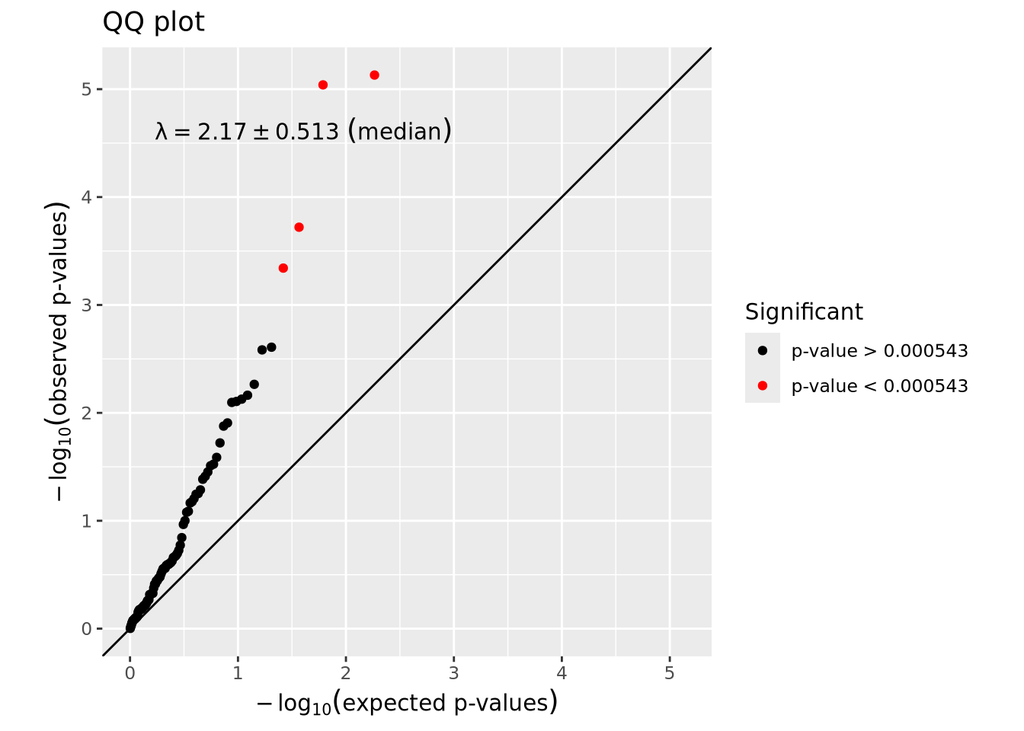

```
>
> $plasma.infect.num
```

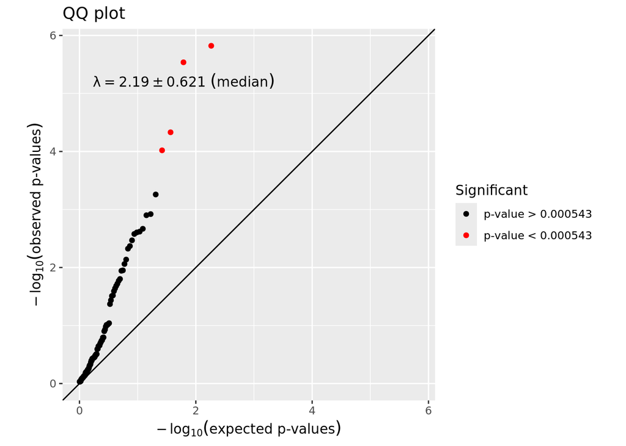

```
>
> $plasma.infect.bi
```

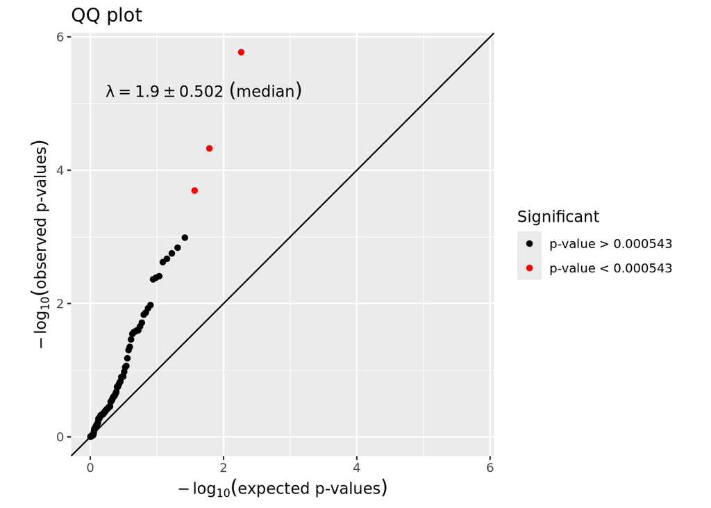

```
>
> $plasma.comp.out
```

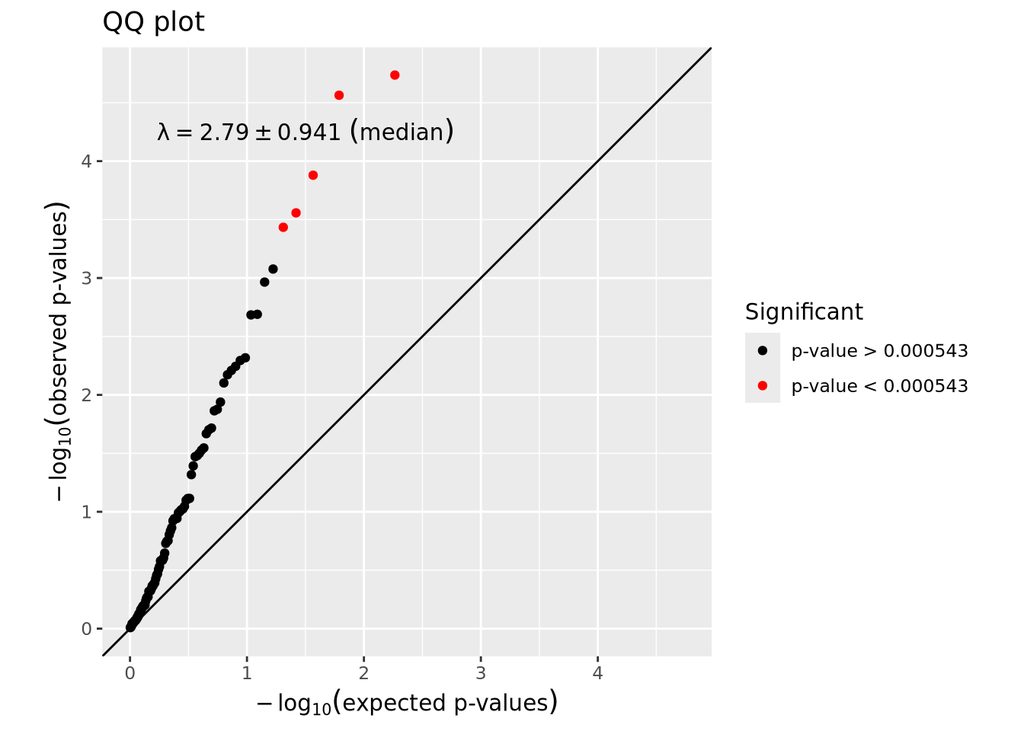

```
>
> $plasma.infect.bi.new
```

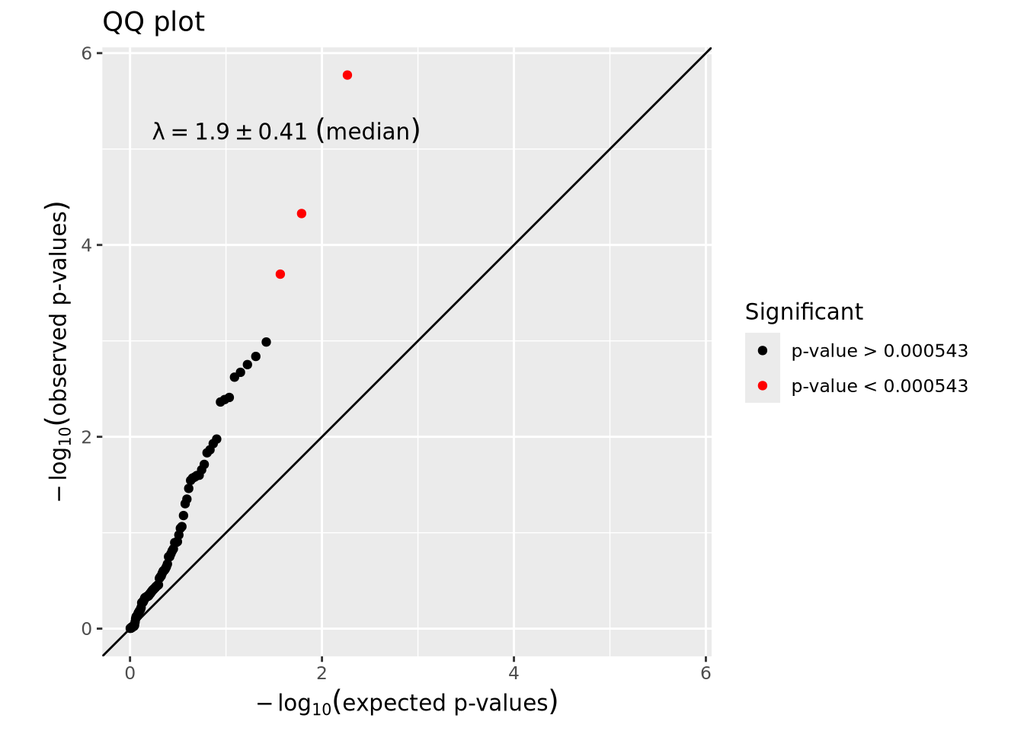

```
>
> $plasma.female
```

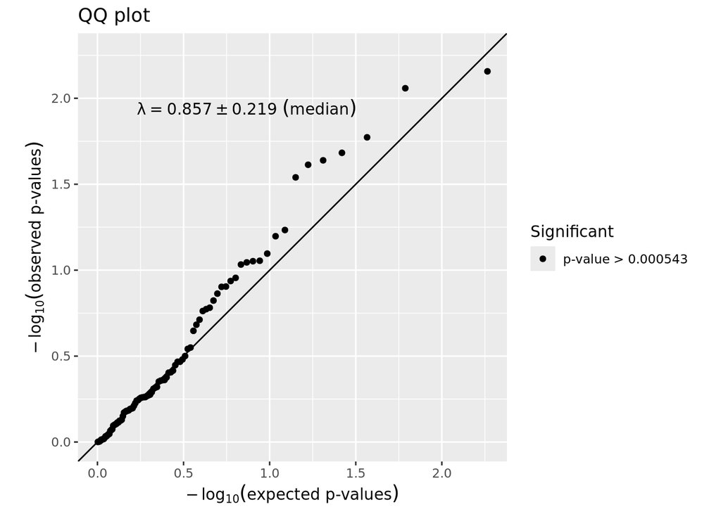

```
>
> $plasma.age
```

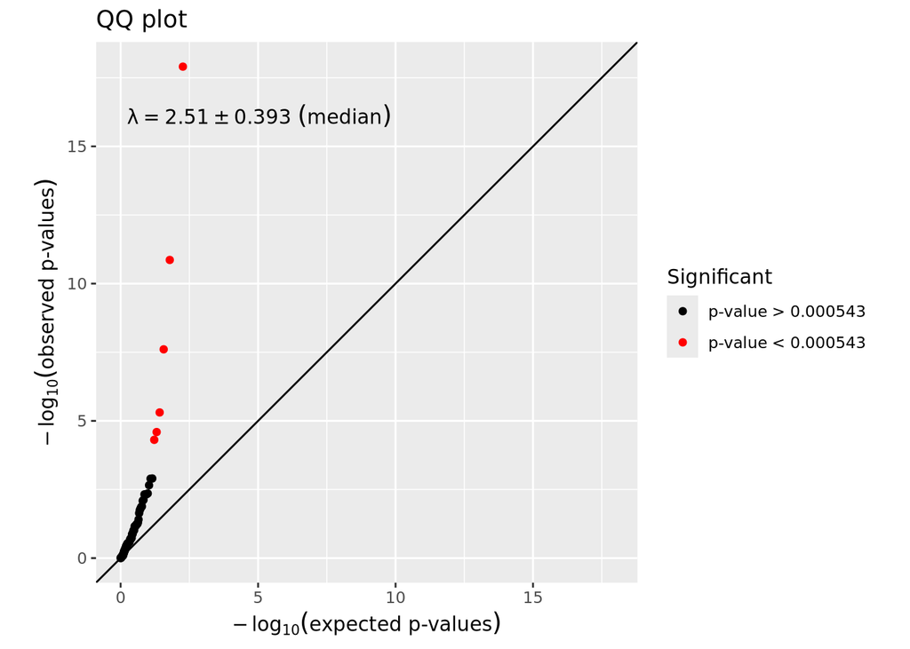

```
>
> $plasma.infect.fct.fulladj
```

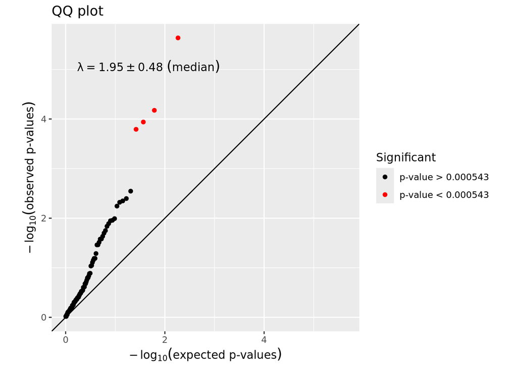

```
>
> $plasma.infect.num.fulladj
```

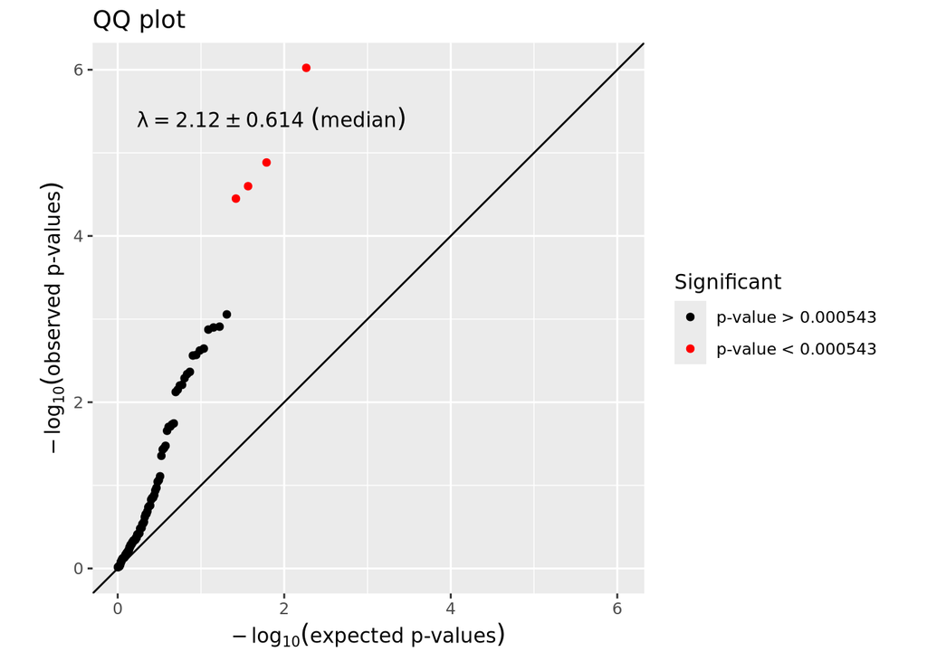

```
>
> $plasma.infect.bi.fulladj
```

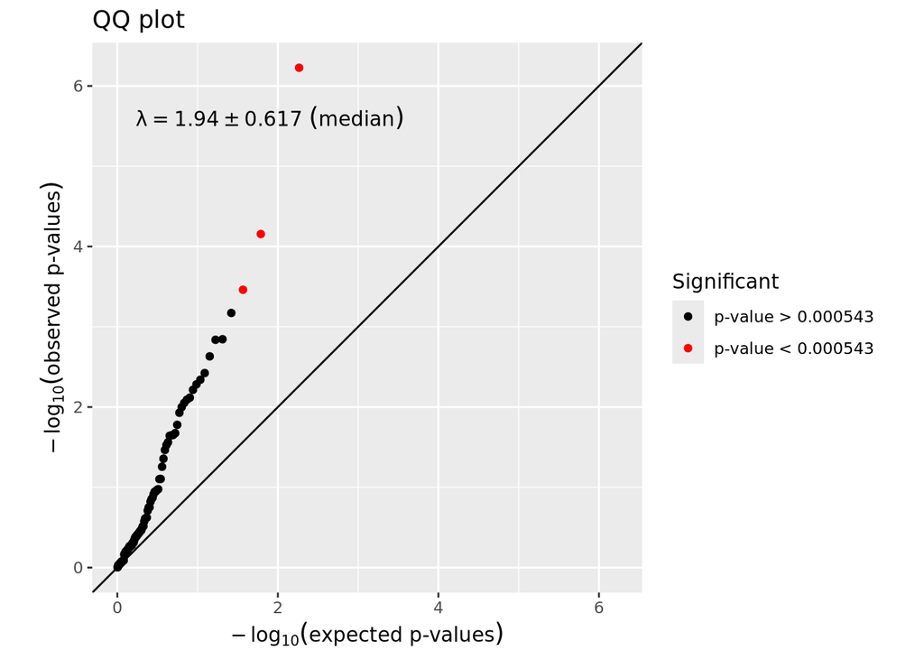

```
>
> $plasma.comp.out.fulladj
```

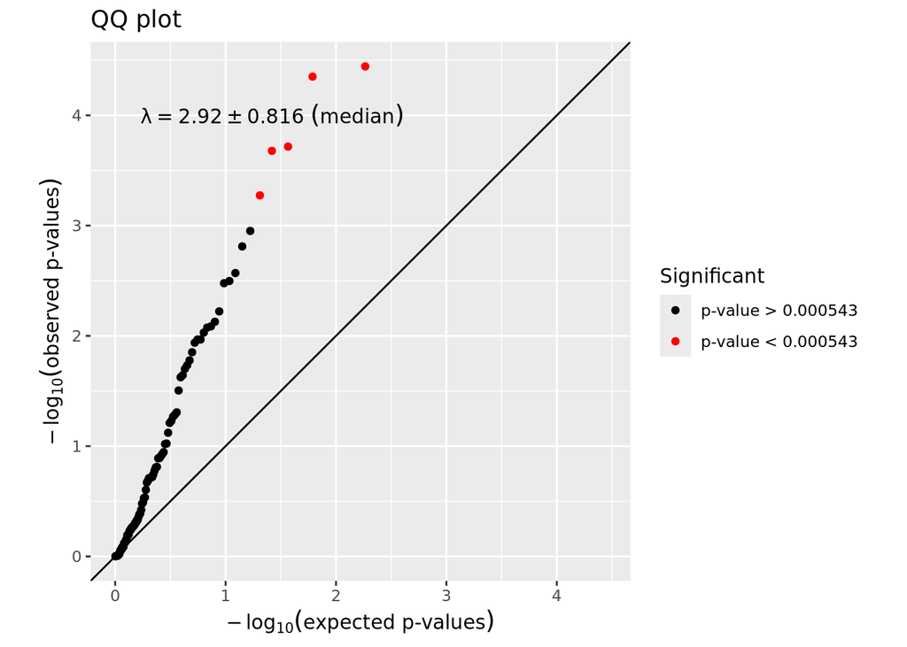

```
>
> $plasma.infect.bi.new.fulladj
```

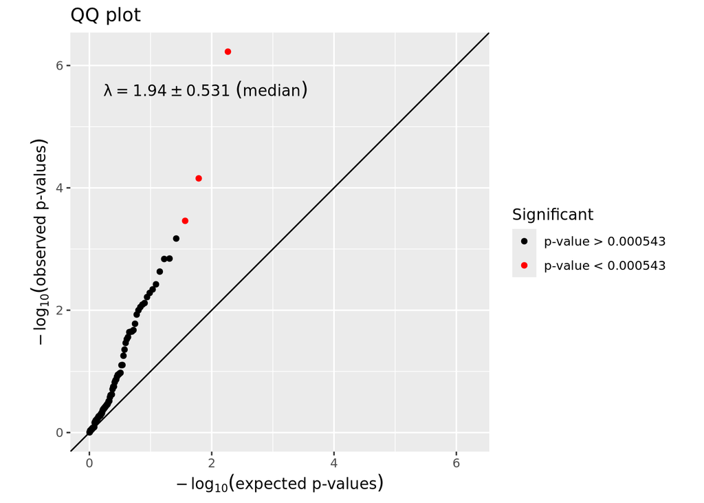